# simon-5502-10-slides

## Topics to be covered

- What you will learn
  - Hierarchical models
  - Hypothetical litter weights
  - Cluster randomized trials
  - Within cluster comparisons

## Hierarchical data

- Moving beyond the independence assumption
- Correlation within clusters

## Examples of hierarchical data, 1 of 2

- Body parts
  - Left eye/right eye
  - Teeth
  - Skin patches
- Human families
- Animal litters

## Examples of hierarchical data, 2 of 2

- Clinics/hospitals
- Communities
- Repeated measurements

## Longitudinal data (topic for next module)

- Measurements taken at different times
  - Emphasis in changes over time

## Between and within cluster comparisons

- Positive correlation
  - Improves precision of within cluster comparisons
  - Hurts precision of between cluster comparisons
- Example with litters
  - Medication administered during pregnancy
  - Medication administered after birth

## Basic notation, 1 of 2

- $Y_{ij}$
  - i defines cluster
    - i=1,…,a
  - j defines individual within cluster
    - j=1,…,n

## Basic notation, 2 of 2

- $Y_{ij} = \mu+\alpha_i+\epsilon_{ij}$
  - $\mu$ unknown constant
  - $\alpha_i$ is normally distributed
    - $SD(\alpha_i)=\sigma_{between}$
  - $\epsilon_{ij}$ is normally distributed
    - $SD(\epsilon_i)=\sigma_{within}$

## Some basic results

- $SD(Y_{ij})=\sigma_{total} = \sqrt{\sigma^2_{between}+\sigma^2_{within}}$
- $SD(\bar{Y}_{..})=\sqrt{\frac{\sigma^2_{between}}{a}+\frac{\sigma^2_{within}}{an}}$
- $Corr(Y_{ij}, Y_{ik})=\frac{\sigma^2_{between}}{\sigma^2_{between}+\sigma^2_{within}}$
  - Intraclass correlation (ICC)

## Expected mean squares, 1 of 2

- $MS(between) = \frac{1}{a-1}\Sigma n(\bar{Y}_{i.}-\bar{Y}_{..})^2$
  - $E[MS(between)] = n\sigma^2_{between}+\sigma^2_{within}$

## Expected mean squares, 2 of 2

- $MS(within) = \frac{1}{a(n-1)}\Sigma\Sigma(\bar{Y}_{ij}-\bar{Y}_{i.})^2$
  - $E[MS(within)] = \sigma^2_{within}$

## Break #1

- What you have learned
  - Hierarchical models
- What’s coming next
  - Hypothetical litter weights

## Description of litter weights data, 1 of 3

```
data_dictionary: litter-weights.sav
```

```
description: |
  Hypothetical data simulated to  illustrate analysis issues  associated with random litter effects.
```

```
source: |
  Sobin, Christina; Golub, Mari (2020),  "Data for: Statistical Modeling with  Litter as a Random Effect in Mixed  Models to Manage Intralitter  Likeness", Mendeley Data, V1,  doi: 10.17632/bwptvj2cmz.1
```

## Description of litter weights data, 2 of 3

```
ID:
  label: ID number for each animal
  range: 1 to 180
LITTER:
  label: ID number for each litter
  range: 1 to 30
SEX:
  label: Unspecified sex
  range: 1 to 2
```

## Description of litter weights data, 3 of 3

```
GRP:
  label: Unspecified group
  range: 1 to 3
WGTP21:
  label: Weight
  units: Unspecified
```

## Layout of full dataset

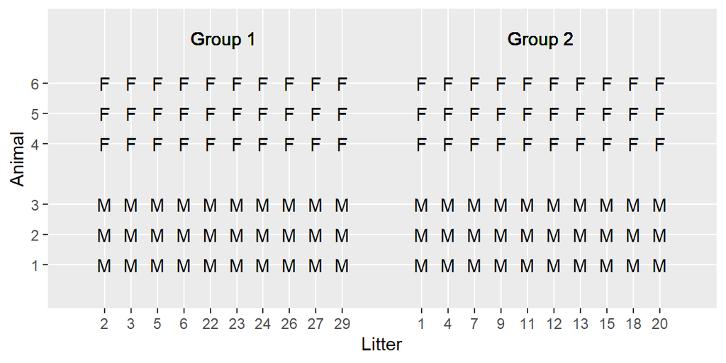

## Layout for two sample t-test

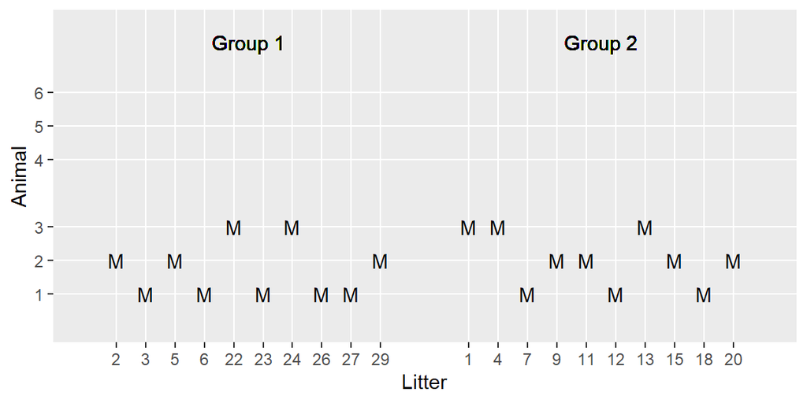

## Layout for the paired t-test

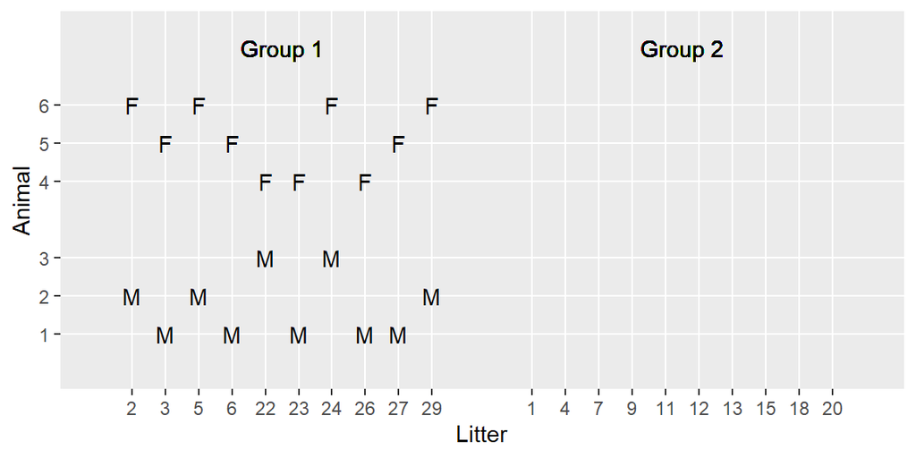

## Why you need to accommodate non-independence

- Increase in power and precision
- Combine multiple tests into single framework
- Handle missing data
- Allows more sophisticated analyses

## How much more power/precision?

- Only for simple cases
  - Tedious but not difficult to extend
- Within cluster comparisons standard error
  - $\sqrt{\frac{\sigma^2_{within}}{an}}$
  - $\sqrt{\frac{\sigma^2_{total}}{an}(1-\rho_{ICC})}$
- Between cluster comparisons standard error
  - $\sqrt{\frac{\sigma^2_{within}}{an}+\frac{\sigma^2_{between}}{a}}$
  - $\sqrt{\frac{\sigma^2_{total}}{an}(1+(n-1) \rho_{ICC})}$

## Pseudo-replication

- Hypothetical study of water contamination
  - Drill 5 wells
  - Sample 4 times at each well
  - Treat as 20 independent observations
- Standard error is not
  - $\sqrt{\frac{\sigma^2_{total}}{an}}$
- Standard error is
  - $\sqrt{\frac{\sigma^2_{total}}{an}(1+(n-1) \rho_{ICC})}$

## Design considerations

- Within cluster comparisons always have greater precision and power
  - Not always possible
- Best to increase number of clusters
  - Not always economical

## Degrees of freedom

- df = N - k
  - k = number of estimated parameters
  - What is N?
    - N=5? (Number of wells)
    - N=20? (Number of water samples)

## Break #2

- What you have learned
  - Hypothetical litter weights
- What’s coming next
  - Cluster randomized trials

## Design

- Designate two treatments
  - i=1,2
  - Possible to use three or more treatments
- Randomly assign clusters
  - j=1,…,b
  - Entire cluster gets same treatment
  - Possible to have unequal numbers within each treatment
- Randomly select patients within clusters
  - k=1,…,n
  - Possible to have unequal numbers within each cluster

## Glimpse of original data

```
Rows: 10
Columns: 7
$ Subject <dbl> 1, 2, 3, 4, 5, 6, 7, 8, 9, 10
$ NoROM   <dbl> 35, 110, 101, 99, 126, 118, 117, 73, 95, 110
$ NoVAS   <dbl> 5.3, 2.0, 1.1, 6.3, 4.0, 0.9, 2.0, 6.1, 5.2, 2.2
$ TENSROM <dbl> 50, 90, 110, 103, 137, 89, 70, 68, 38, 87
$ TENSVAS <dbl> 3.8, 7.3, 3.6, 4.0, 1.9, 5.6, 6.6, 4.1, 7.7, 4.8
$ SWDROM  <dbl> 64, 120, 116, 135, 150, 100, 74, 93, 100, 73
$ SWDVAS  <dbl> 7.0, 1.6, 2.4, 0.8, 1.0, 2.0, 8.0, 4.5, 2.3, 4.0
```

```
Rows: 30
Columns: 3
$ Subject   <dbl> 1, 1, 1, 2, 2, 2, 3, 3, 3, 4, 4, 4, 5, 5, 5, 6, 6, 6, 7, 7, …
$ treatment <chr> "no", "tens", "swd", "no", "tens", "swd", "no", "tens", "swd…
$ rom       <dbl> 35, 50, 64, 110, 90, 120, 101, 110, 116, 99, 103, 135, 126, …
```

## Descriptive statistics

```
# A tibble: 3 × 3
  treatment rom_mean rom_sd
  <chr>        <dbl>  <dbl>
1 no            98.4   26.8
2 swd          102.    28.0
3 tens          84.2   29.1
```

## Plot by subject

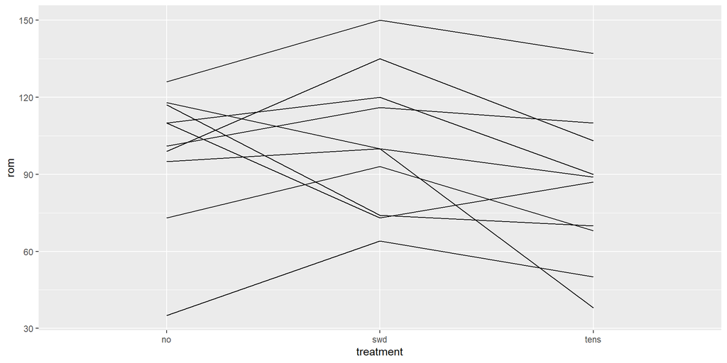

## Mixed model, 1

```r
library(lme4)

m1 <- lmer(
  rom ~ treatment + (1 | Subject),
  data=oa_2)
```

## Mixed model, 2

```
Linear mixed model fit by REML ['lmerMod']
Formula: rom ~ treatment + (1 | Subject)
   Data: oa_2

REML criterion at convergence: 253.5

Scaled residuals:
    Min      1Q  Median      3Q     Max
-1.8326 -0.4790  0.1129  0.6702  1.4533
```

- (You can ignore this part of the output)

## Mixed model, 3

```
Random effects:
 Groups   Name        Variance Std.Dev.
 Subject  (Intercept) 481.7    21.95
 Residual             301.8    17.37
Number of obs: 30, groups:  Subject, 10
```

- $\sigma_{between}$ = 21.95
- $\sigma_{within}$ = 17.37
- ICC = 481.7/(481.7+301.8)
  - = 0.61

## Mixed model, 4

```
Fixed effects:
              Estimate Std. Error t value
(Intercept)     98.400      8.851  11.117
treatmentswd     4.100      7.769   0.528
treatmenttens  -14.200      7.769  -1.828
```

- $\bar{X}_{swd}-\bar{X}_{no}$ = 4.1
  - t is close to zero, accept H0
- $\bar{X}_{tens}-\bar{X}_{no}$ = -14.2
  - Goes in the wrong direction!!!
  - t is close to zero, accept H0

## Mixed model, 5

```
Correlation of Fixed Effects:
            (Intr) trtmnts
treatmntswd -0.439
treatmnttns -0.439  0.500
```

- (You can ignore this part of the output)

## Live demo, two sample t-test

## Break #3

- What you have learned
  - Cluster randomized trials
- What’s coming next
  - Within cluster comparisons

## Physical activity study, data dictionary

This data set is from a cluster randomized trial in Norway. Students from 57 schools were recruited for the study. 29 schools were randomly assigned to physical activity intervention and 28 schools served as a control group. The outcomes were changes in various measures of cardiometabolic health.

## Counts by school (partial listing)

```
   School Group_allocation  n
1       1          Control 11
2       2          Control 10
3       3     Intervention 10
4       4     Intervention 28
5       6     Intervention 19
6       8          Control  9
7       9     Intervention 27
8      10          Control 11
9      12          Control 32
10     13          Control 20
```

## Boxplot of change scores

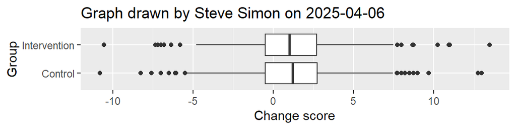

## Mixed model, 1

```r
library(lme4)

m2 <- lmer(
  change_score ~ Group_allocation + (1 | School),
  data=pa_1)
```

## Mixed model, 2

```
Linear mixed model fit by REML ['lmerMod']
Formula: change_score ~ Group_allocation + (1 | School)
   Data: pa_1

REML criterion at convergence: 5013.3

Scaled residuals:
    Min      1Q  Median      3Q     Max
-4.6825 -0.5667  0.0021  0.5684  4.5686
```

- (You can ignore this part of the output)

## Mixed model, 3

```
Random effects:
 Groups   Name        Variance Std.Dev.
 School   (Intercept) 1.590    1.261
 Residual             6.578    2.565
Number of obs: 1043, groups:  School, 57
```

## Mixed model, 4

```
Fixed effects:
                             Estimate Std. Error t value
(Intercept)                   1.34079    0.27058   4.955
Group_allocationIntervention -0.01049    0.38135  -0.028
```

- $\bar{X}_{Intervention}-\bar{X}_{Control}$ = -0.01
  - t is close to zero, accept H0

## Mixed model, 5

```
Correlation of Fixed Effects:
            (Intr)
Grp_llctnIn -0.710
```

- (You can ignore this part of the output)

## Summary

- What you have learned
  - Hierarchical models
  - Hypothetical litter weights
  - Cluster randomized trials
  - Within cluster comparisons